# BOO 2025 - Example Analysis

Script 4: PCA - Questions

Hala Saab

2025-05-23

> In this script, you will perform principal component analysis (PCA) to further explore patterns in the project data.

# 1 Setup

## 1.1 Clean

As before, we perform several setup steps at the start of the script to ensure our work is reproducible and clear.

**Exercise 1: Download the R markdown template, clean your environment, and set the following variables:**

- `root_dir` - project folder
- `cpm_path` - location of the `cpmData` object
- `metadata_path` - location of the `metaData` object

```r
 rm(list = ls())
```

```r
cpm_path <- file.path("Output/cpm_store.csv")
metadata_path <- file.path("Output/metadata_store.csv")
```

## 1.2 Packages

Two new packages are introduced in this script:

- `ComplexHeatmap` allows the drawing and annotation of heatmaps in R
- `circlize` allows for the drawing of circular plots, but is also used by `ComplexHeatmap` for colour functions like `colorRamp2()`

**Exercise 2: Load these packages alongside `tidyverse` into your R environment:**

```r
library(tidyverse)
```

```r
library(ComplexHeatmap)
library(circlize)
```

## 1.3 Load data

**Exercise 3: Load the CPM and metadata into your R environment:**

```r
metadata  <- read.csv("output/metadata_store.csv")

cpmData  <- read.csv("output/cpm_store.csv")
```

```r
cpmData <- cpmData %>% column_to_rownames(var = "X")
```

# 2 PCA

## 2.1 Calculate

In high dimensional data (such as this data with around 10,000 genes), principal components (PCs) can be calculated and used to explore patterns. PCs can be thought of as a new axis in the data that captures the most variance possible in the fewest variables.

**Exercise 4: Use the `prcomp()` function to calculate PCs of the `cpmData`:**

```r
pcs <- prcomp(t(cpmData))


# if(!is.null(pca_results)) {
#   print("PCA successful. Summary of first few PCs:")
#   print(summary(pca_results)$importance[,1:min(5, ncol(summary(pca_results)$importance))])
# } else {
#   print("PCA failed. 'pca_results' is NULL.")
# }



#The tol argument in prcomp() is a threshold used to determine which principal components are kept
```

Tolerance (or `tol`) can be adjusted to create more or fewer PCs, where a lower tolerance generates a higher number. If this argument is not set, the PCs calculated will capture the full variability of the CPM data.

## 2.2 Variance explained

**Exercise 5: Use the output of `prcomp()` to explore your PCs and calculate the variance in CPM values that they explain:**

**Hint**

Variance explained is the SD squared divided by the sum of the variance for all PCs.

```r
# insure pca_results exists and is not NULL (i.e., PCA ran successfully)
summary(pcs)
```

```
## Importance of components:
##                             PC1       PC2       PC3       PC4       PC5
## Standard deviation     2198.956 1003.6131 939.54144 741.55150 568.79036
## Proportion of Variance    0.494    0.1029   0.09018   0.05618   0.03305
## Cumulative Proportion     0.494    0.5969   0.68705   0.74323   0.77628
##                              PC6       PC7       PC8      PC9      PC10
## Standard deviation     545.09636 468.57003 412.97514 390.7784 352.78755
## Proportion of Variance   0.03035   0.02243   0.01742   0.0156   0.01271
## Cumulative Proportion    0.80663   0.82906   0.84649   0.8621   0.87480
##                             PC11      PC12      PC13      PC14      PC15
## Standard deviation     327.35198 298.78293 279.93243 274.78382 227.01306
## Proportion of Variance   0.01095   0.00912   0.00801   0.00771   0.00526
## Cumulative Proportion    0.88575   0.89487   0.90287   0.91059   0.91585
##                             PC16      PC17      PC18      PC19      PC20
## Standard deviation     220.00826 213.45340 204.93060 200.98031 181.25431
## Proportion of Variance   0.00494   0.00465   0.00429   0.00413   0.00336
## Cumulative Proportion    0.92080   0.92545   0.92974   0.93387   0.93722
##                             PC21      PC22      PC23      PC24      PC25
## Standard deviation     169.65464 166.83689 160.46640 155.65464 154.98114
## Proportion of Variance   0.00294   0.00284   0.00263   0.00248   0.00245
## Cumulative Proportion    0.94017   0.94301   0.94564   0.94811   0.95057
##                             PC26      PC27      PC28      PC29      PC30
## Standard deviation     151.50044 150.68193 145.72638 142.61420 139.23268
## Proportion of Variance   0.00234   0.00232   0.00217   0.00208   0.00198
## Cumulative Proportion    0.95291   0.95523   0.95740   0.95948   0.96146
##                             PC31      PC32      PC33      PC34      PC35
## Standard deviation     134.24048 131.88059 130.70782 128.76574 127.30248
## Proportion of Variance   0.00184   0.00178   0.00175   0.00169   0.00166
## Cumulative Proportion    0.96330   0.96508   0.96682   0.96852   0.97017
##                             PC36      PC37      PC38      PC39      PC40
## Standard deviation     124.76587 123.54903 123.16174 120.88253 119.54352
## Proportion of Variance   0.00159   0.00156   0.00155   0.00149   0.00146
## Cumulative Proportion    0.97176   0.97332   0.97487   0.97636   0.97782
##                             PC41     PC42      PC43      PC44      PC45
## Standard deviation     117.60048 117.0056 115.86497 114.42701 113.46455
## Proportion of Variance   0.00141   0.0014   0.00137   0.00134   0.00132
## Cumulative Proportion    0.97924   0.9806   0.98201   0.98335   0.98466
##                             PC46      PC47      PC48      PC49      PC50
## Standard deviation     111.64801 111.03684 110.03163 108.94036 107.71694
## Proportion of Variance   0.00127   0.00126   0.00124   0.00121   0.00119
## Cumulative Proportion    0.98593   0.98719   0.98843   0.98964   0.99083
##                             PC51      PC52     PC53      PC54     PC55     PC56
## Standard deviation     106.65140 105.01428 103.5349 101.75176 99.61684 98.29655
## Proportion of Variance   0.00116   0.00113   0.0011   0.00106  0.00101  0.00099
## Cumulative Proportion    0.99199   0.99312   0.9942   0.99527  0.99628  0.99727
##                            PC57     PC58     PC59      PC60
## Standard deviation     96.77524 95.35079 90.91670 1.498e-12
## Proportion of Variance  0.00096  0.00093  0.00084 0.000e+00
## Cumulative Proportion   0.99823  0.99916  1.00000 1.000e+00
```

```r
# Calculate variance explained
var_explained =
  data.frame(PC = 1:nrow(metadata),
             var_explained = round(pcs$sdev^2 / sum(pcs$sdev^2), 3))

# Inspect
var_explained
```

| PC | var_explained |
| --- | --- |
| 1 | 0.494 |
| 2 | 0.103 |
| 3 | 0.090 |
| 4 | 0.056 |
| 5 | 0.033 |
| 6 | 0.030 |
| 7 | 0.022 |
| 8 | 0.017 |
| 9 | 0.016 |
| 10 | 0.013 |

[output cut: 50 more lines]

[output not shown]

## 2.3 Screeplot

A screeplot can be used to visualize how each subsequent PC captures less and less of the total variance in the data.

**Exercise 6: Plot the top 20 calculated PCs against the variance they explain to generate a screeplot:**

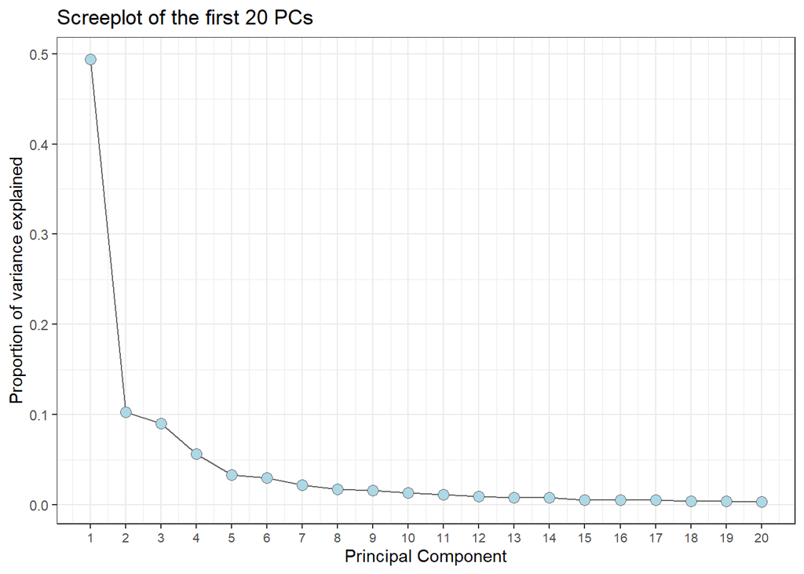

```r
# n
var_explained %>%
  # Subset variance explained to include only the first 20 PCs
  filter(PC <= 20) %>%
  # Plot PC against variance explained
  ggplot(aes(x = PC, y = var_explained)) +
  # Draw a line between points
  geom_line(color = "grey40") +
  # Draw points for each PC
  geom_point(color = "grey40", fill = 'lightblue', shape = 21, size = 3) +
  # Label x axis at integer values between 1 and 20
  scale_x_continuous(breaks = c(seq(1,20))) +
  xlab("Principal Component") +
  ylab("Proportion of variance explained") +
  ggtitle("Screeplot of the first 20 PCs") +
  theme_bw() +
  theme(axis.text.x = element_text(size = 8))
```